# Netflix Text Analysis

## Tokenization

Here we will start our process of tikenization for our “description” column.

```r
library(dplyr)
tidy_netflix_description <- netflix_titles %>%
select("show_id","description")
head(tidy_netflix_title)
```

| show_id | description |
| --- | --- |
| s1 | As her father nears the end of his life, filmmaker Kirsten Johnson stages his death in inventive and comical ways to help them both face the inevitable. |
| s2 | After crossing paths at a party, a Cape Town teen sets out to prove whether a private-school swimming star is her sister who was abducted at birth. |
| s3 | To protect his family from a powerful drug lord, skilled thief Mehdi and his expert team of robbers are pulled into a violent and deadly turf war. |
| s4 | Feuds, flirtations and toilet talk go down among the incarcerated women at the Orleans Justice Center in New Orleans on this gritty reality series. |
| s5 | In a city of coaching centers known to train India’s finest collegiate minds, an earnest but unexceptional student and his friends navigate campus life. |
| s6 | The arrival of a charismatic young priest brings glorious miracles, ominous mysteries and renewed religious fervor to a dying town desperate to believe. |

```r
Netflx<-tidy_netflix_description %>%
   unnest_tokens(
    output = word,
    input = description,# our column of interest
    token = 'words',
    drop = FALSE
  ) %>%
  ungroup()
head(Netflx,24)# show just first 24 rows of words
```

| show_id | description | word |
| --- | --- | --- |
| s1 | As her father nears the end of his life, filmmaker Kirsten Johnson stages his death in inventive and comical ways to help them both face the inevitable. | as |
| s1 | As her father nears the end of his life, filmmaker Kirsten Johnson stages his death in inventive and comical ways to help them both face the inevitable. | her |
| s1 | As her father nears the end of his life, filmmaker Kirsten Johnson stages his death in inventive and comical ways to help them both face the inevitable. | father |
| s1 | As her father nears the end of his life, filmmaker Kirsten Johnson stages his death in inventive and comical ways to help them both face the inevitable. | nears |
| s1 | As her father nears the end of his life, filmmaker Kirsten Johnson stages his death in inventive and comical ways to help them both face the inevitable. | the |
| s1 | As her father nears the end of his life, filmmaker Kirsten Johnson stages his death in inventive and comical ways to help them both face the inevitable. | end |
| s1 | As her father nears the end of his life, filmmaker Kirsten Johnson stages his death in inventive and comical ways to help them both face the inevitable. | of |
| s1 | As her father nears the end of his life, filmmaker Kirsten Johnson stages his death in inventive and comical ways to help them both face the inevitable. | his |
| s1 | As her father nears the end of his life, filmmaker Kirsten Johnson stages his death in inventive and comical ways to help them both face the inevitable. | life |
| s1 | As her father nears the end of his life, filmmaker Kirsten Johnson stages his death in inventive and comical ways to help them both face the inevitable. | filmmaker |

[output cut: 14 more lines]

```r
NA
```

Let’s create a frequency table of words used in “description”:

```r
Netflx<- Netflx %>%
unnest_tokens(word, description) %>%
count(word, sort = TRUE)
Netflx
```

| word | n |
| --- | --- |
| a | 290482 |
| the | 201417 |
| to | 162607 |
| and | 153951 |
| of | 130007 |
| in | 109057 |
| his | 83797 |
| with | 55815 |
| her | 54239 |
| an | 49130 |

[output cut: 990 more lines]

Now, you can remove the stop words from your data frame:

```r
Netflx <- Netflx %>%
anti_join(stop_words)
Netflx # after removing stop_words
```

| word | n |
| --- | --- |
| life | 20492 |
| family | 14063 |
| world | 12600 |
| love | 12459 |
| woman | 11471 |
| friends | 10725 |
| series | 9242 |
| documentary | 8117 |
| school | 8032 |
| home | 7927 |

[output cut: 990 more lines]

Next, run the following to plot the words in Netflix Description that appear more than 50 times. You will see in this situation almost nothing to understand so, why not filter based on the frequency. (try to change the number of frequency to other frequencies 3000)

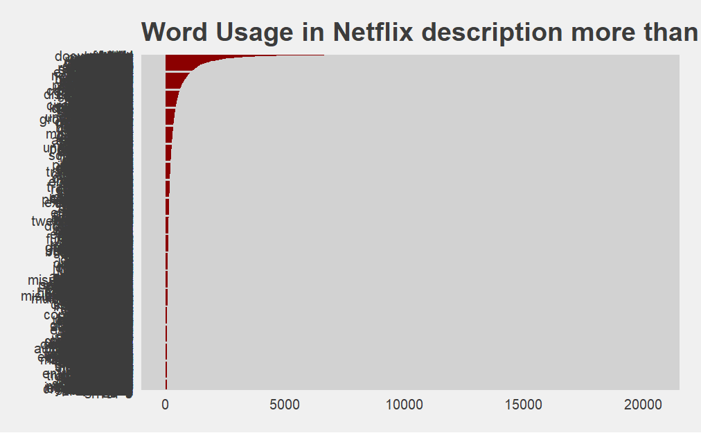

```r
Netflx %>%
filter(n > 50) %>%
mutate(word = reorder(word, n)) %>%
ggplot(aes(word, n)) +
geom_col(fill = "darkred") +
theme_fivethirtyeight() +
xlab(NULL) +
ylab("Word Count") +
  coord_flip() +
ggtitle("Word Usage in Netflix description more than 50 times")
```

[figure not shown]

```r
Netflx %>%
filter(n > 3000) %>%
mutate(word = reorder(word, n)) %>%
ggplot(aes(word, n)) +
geom_col(fill = "darkred") +
theme_fivethirtyeight() +
xlab(NULL) +
ylab("Word Count") +
  coord_flip() +
ggtitle("Word Usage in Netflix description more than 50 times")
```

Why not group by show_id? Let’s do it!

```r
Netflx_s<-tidy_netflix_description %>%
   unnest_tokens(
    output = word,
    input = description,# our column of interest
    token = 'words',
    drop = FALSE
  ) %>%
  ungroup()
# get sentiment via inner join
netflix_sentiment = Netflx_s %>%
  inner_join(get_sentiments("afinn")) %>%
  group_by(show_id, description) %>% # group by show_id and description
  dplyr::summarise(sentiment=sum(value)) %>% # value will be the numerical sentiment given and we want to group by show_id
  ungroup()
netflix_sentiment
```

| show_id | description | sentiment |
| --- | --- | --- |
| s1 | As her father nears the end of his life, filmmaker Kirsten Johnson stages his death in inventive and comical ways to help them both face the inevitable. | 0 |
| s10 | A woman adjusting to life after a loss contends with a feisty bird that's taken over her garden — and a husband who's struggling to find a way forward. | -5 |
| s100 | Four women — a chef, a single mom, an heiress and a job seeker — dig into love and work, with a generous side of midlife crises, in pre-pandemic LA. | 5 |
| s1001 | A brash but brilliant Indian intelligence agent leads a covert operation to nab the mastermind behind a series of attacks threatening national security. | 1 |
| s1003 | Workaholic Will puts his humdrum life in LA on hold to fulfill his grandpa's last wish: visiting Mexico City's most iconic sights and falling in love. | 5 |
| s1004 | A shy teen with the power to turn invisible must get it under control to help defend his neighborhood, putting aside the pursuit of his artistic dream. | 2 |
| s1005 | Young koala caretaker Izzy Bee and her family rescue cuddly creatures in need and help them head back into the wild on Australia’s Magnetic Island. | 4 |
| s1006 | For Rohan and his magical pal, Keymon, a trip to visit their grandmother turns into the rescue mission of a lifetime when she is kidnapped by aliens! | 2 |
| s1007 | A time machine sends Motu and Patlu back to the dinosaur period, but the real trouble starts when the reptiles travel back to the present day with them! | -2 |
| s1008 | While returning a goldfish and an octopus from an aquarium to the sea, Motu and Patlu must also save the goldfish’s family from a mean, tentacled queen. | 2 |

[output cut: 990 more lines]

Next! We may filter those show_id which are in a given range of sentiment.

[figure not shown]

```r
netflix_sentiment%>%
filter(sentiment >=12) %>%
ggplot(aes(show_id, sentiment)) +
theme_fivethirtyeight() +
geom_col() +
xlab(NULL) +
coord_flip() +
ylab("Word Count") +
ggtitle("Sentiment greater than 12 in Netflix show_id", subtitle = "Sentiment Analysis Using NRC")
```

## Sentiment Lexicons

There are three mostly used lexicons in R:

```r
get_sentiments("bing")
```

| word | sentiment |
| --- | --- |
| 2-faces | negative |
| abnormal | negative |
| abolish | negative |
| abominable | negative |
| abominably | negative |
| abominate | negative |
| abomination | negative |
| abort | negative |
| aborted | negative |
| aborts | negative |

[output cut: 990 more lines]

```r
get_sentiments("afinn")
```

| word | value |
| --- | --- |
| abandon | -2 |
| abandoned | -2 |
| abandons | -2 |
| abducted | -2 |
| abduction | -2 |
| abductions | -2 |
| abhor | -3 |
| abhorred | -3 |
| abhorrent | -3 |
| abhors | -3 |

[output cut: 990 more lines]

```r
get_sentiments("nrc")
```

| word | sentiment |
| --- | --- |
| abacus | trust |
| abandon | fear |
| abandon | negative |
| abandon | sadness |
| abandoned | anger |
| abandoned | fear |
| abandoned | negative |
| abandoned | sadness |
| abandonment | anger |
| abandonment | fear |

[output cut: 990 more lines]

Now we will try BING lexicon on description.

```r
Netflx_bing <- Netflx %>%
inner_join(get_sentiments("bing"))
Netflx_bing
```

| word | n | sentiment |
| --- | --- | --- |
| love | 12459 | positive |
| murder | 4828 | negative |
| death | 4632 | negative |
| crime | 4520 | negative |
| mysterious | 4374 | negative |
| falls | 3996 | negative |
| evil | 3547 | negative |
| dark | 3003 | negative |
| leads | 2649 | positive |
| struggles | 2550 | negative |

[output cut: 990 more lines]

### Library “yarr”

We may create some graphs here . They work better if we have also a time variable we may use. Why not try? (exercise for you)

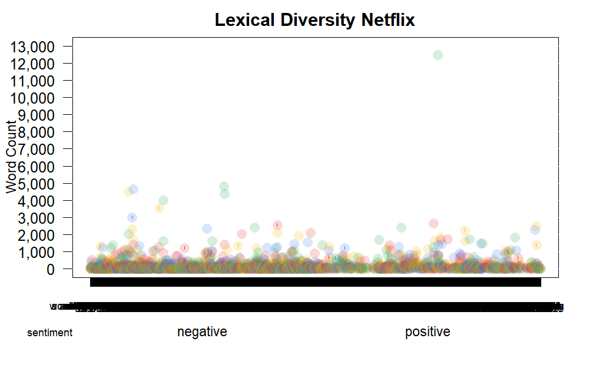

```r
library(yarrr)
pirateplot(formula =  n ~ word + sentiment, #Formula
   data = Netflx_bing, #Data frame
   xlab = NULL, ylab = "Word Count", #Axis labels
   main = "Lexical Diversity Netflix", #Plot title
   pal = "google", #Color scheme
   point.o = .2, #Points
   avg.line.o = 1, #Turn on the Average/Mean line
   theme = 0, #Theme
   point.pch = 16, #Point `pch` type
   point.cex = 1.5, #Point size
   jitter.val = .1, #Turn on jitter to see the songs better
   cex.lab = .9, cex.names = .7) #Axis label size
```

To obtain a better view we may filter some of the words with a given number of frequency:

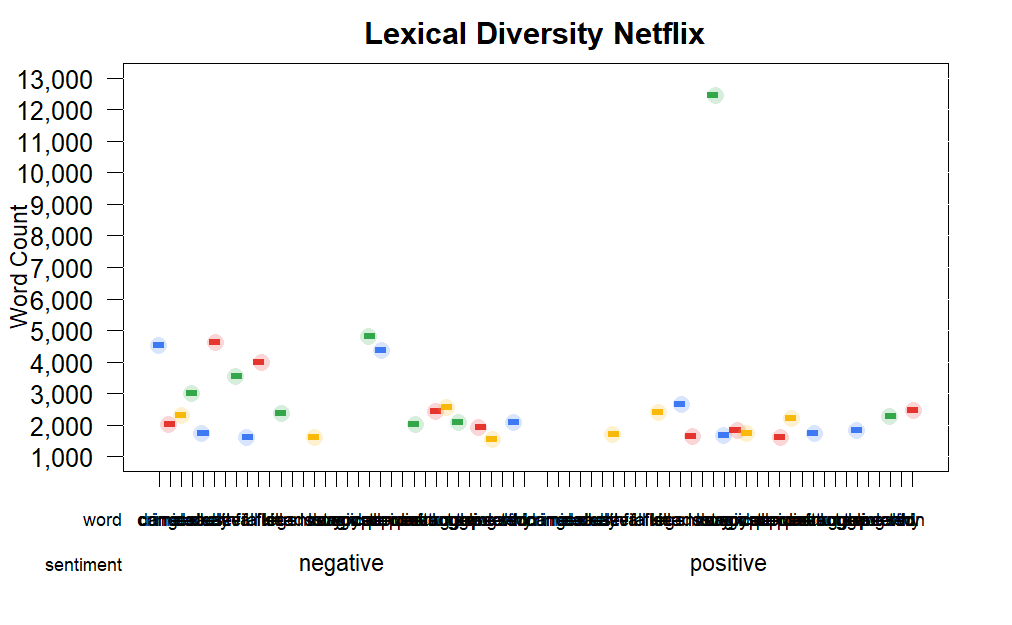

```r
Netflx_bing %>%
  filter(n>=1500) %>%
pirateplot(formula =  n ~ word + sentiment, #Formula
   xlab = NULL, ylab = "Word Count", #Axis labels
   main = "Lexical Diversity Netflix", #Plot title
   pal = "google", #Color scheme
   point.o = .2, #Points
   avg.line.o = 1, #Turn on the Average/Mean line
   theme = 0, #Theme
   point.pch = 16, #Point `pch` type
   point.cex = 1.5, #Point size
   jitter.val = .1, #Turn on jitter to see the songs better
   cex.lab = .9, cex.names = .7) #Axis label size
```

For more reference: https://www.datacamp.com/tutorial/sentiment-analysis-R

```r
Netflx_nrc <- Netflx %>%
inner_join(get_sentiments("nrc"))
Netflx_nrc
```

| word | n | sentiment |
| --- | --- | --- |
| love | 12459 | joy |
| love | 12459 | positive |
| series | 9242 | trust |
| school | 8032 | trust |
| father | 6308 | trust |
| save | 5640 | joy |
| save | 5640 | positive |
| save | 5640 | trust |
| true | 5182 | joy |
| true | 5182 | positive |

[output cut: 990 more lines]

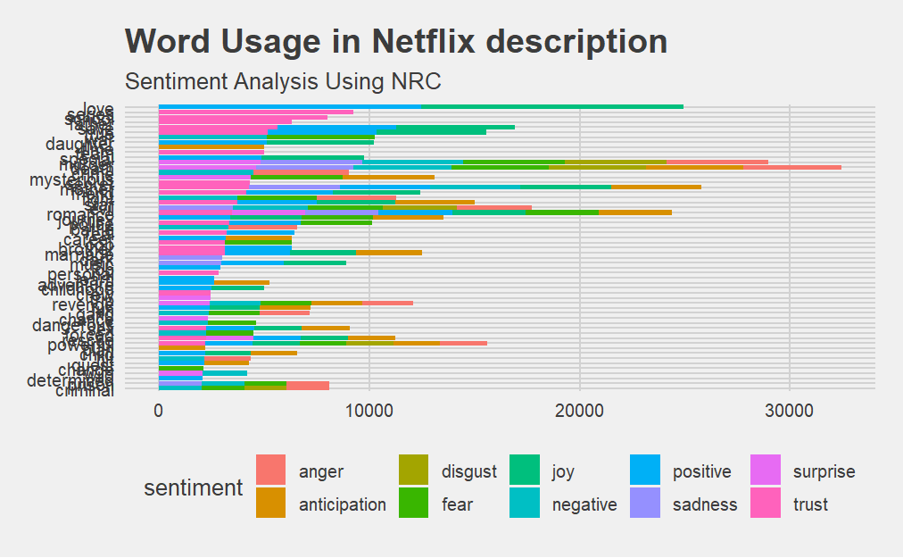

```r
Netflx_nrc %>%
filter(n > 2000) %>%
mutate(word = reorder(word, n)) %>%
ggplot(aes(word, n, fill=sentiment)) +
theme_fivethirtyeight() +
geom_col() +
xlab(NULL) +
coord_flip() +
ylab("Word Count") +
ggtitle("Word Usage in Netflix description", subtitle = "Sentiment Analysis Using NRC")
```

Produce a horizontal bar chart showing positive and negative word usage in Netflix description using the Bing et al. sentiment lexicon.(try to change the value 2000 and observe the words)

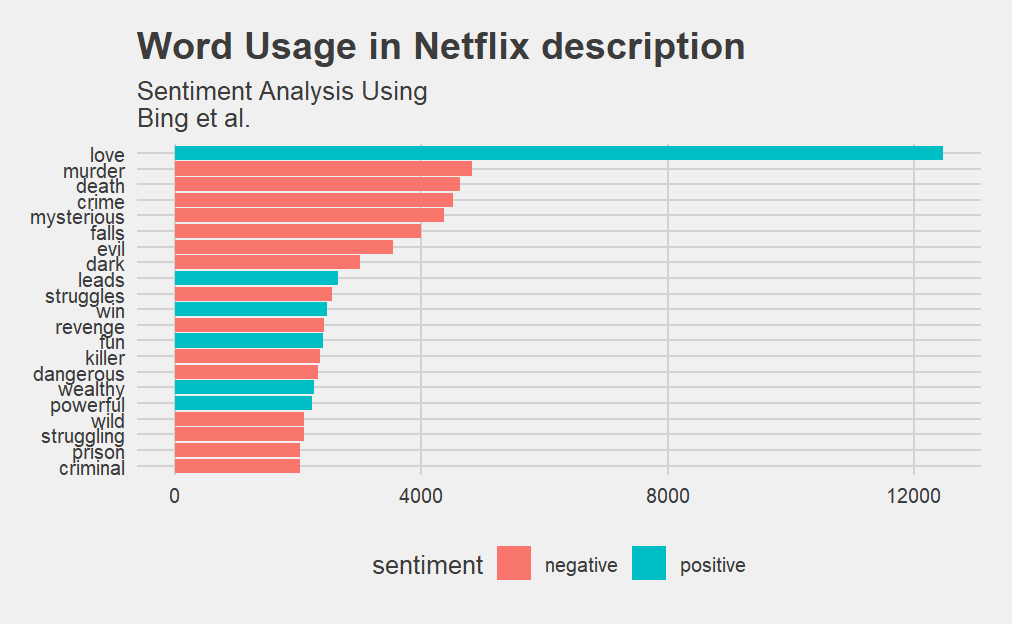

```r
Netflx_bing %>%
filter(n > 2000) %>%
mutate(word = reorder(word, n)) %>%
ggplot(aes(word, n, fill=sentiment)) +
theme_fivethirtyeight() +
geom_col() +
xlab(NULL) +
coord_flip() +
ylab("Word Count") +
ggtitle("Word Usage in Netflix description", subtitle = "Sentiment Analysis Using
Bing et al.")
```

[figure not shown]

```r
Netflx_nrc %>%
filter(n > 2000) %>%
mutate(word = reorder(word, n)) %>%
ggplot(aes(word, n, fill=sentiment)) +
theme_fivethirtyeight() +
geom_col() +
xlab(NULL) +
coord_flip() +
ylab("Word Count") +
ggtitle("Word Usage in Netflix description", subtitle = "Sentiment Analysis Using nrc")
```

Try to filter some of the sentiments as in the examples below. I am interested on knowwing which words are related to the sentiment “surprise” and then “love” in teh description of the Netflix Movies or TV Shows.

```r
Net_nrc_surprise <- get_sentiments("nrc") %>%
filter(sentiment == "surprise")
Net_nrc_surprise
```

| word | sentiment |
| --- | --- |
| abandonment | surprise |
| abduction | surprise |
| abrupt | surprise |
| accident | surprise |
| accidental | surprise |
| accidentally | surprise |
| accolade | surprise |
| advance | surprise |
| affront | surprise |
| aghast | surprise |

[output cut: 522 more lines]

```r
Netflx %>%
inner_join(Net_nrc_surprise)
```

| word | n | sentiment |
| --- | --- | --- |
| murder | 4828 | surprise |
| death | 4632 | surprise |
| mysterious | 4374 | surprise |
| romance | 3484 | surprise |
| trip | 2478 | surprise |
| revenge | 2422 | surprise |
| chance | 2346 | surprise |
| rescue | 2246 | surprise |
| wild | 2102 | surprise |
| unexpected | 1930 | surprise |

[output cut: 324 more lines]

```r
Net_nrc_love <- get_sentiments("nrc") %>%
filter(sentiment == "love")
Net_nrc_love
```

| word | sentiment |
| --- | --- |

```r
Netflx %>%
inner_join(Net_nrc_love)
```

| word | n | sentiment |
| --- | --- | --- |

Try another word and explore some relationships!! We will see how NRC result shows for some of the sentiments and top words.

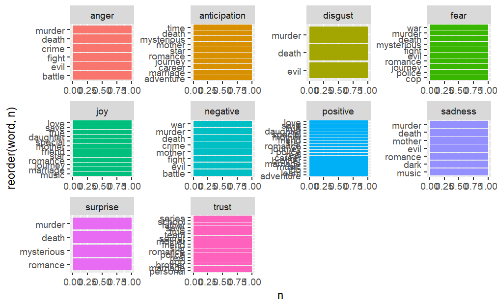

```r
Netflx_nrc %>%
  filter(n>2500) %>% #  filter only those frequency greater than 2000
mutate(word = reorder(word, n)) %>%
count(word,sentiment,sort=TRUE) %>%
group_by(sentiment)%>%
  top_n(n=5) %>%
ungroup() %>%
  ggplot(aes(x=reorder(word,n),y=n,fill=sentiment)) +
  geom_col(show.legend = FALSE) +
  facet_wrap(~sentiment,scales="free") +
  coord_flip()
```

## Comparing Sentiment Lexicons

```r
library(stringr)
library(tidyr)
```

Add more filtering such as “type” because we want more info also on the type of the title if it was a Movie or a TV show.

```r
Netflx_type <- netflix_titles %>%
select("show_id","type","description")
head(Netflx_type)
```

| show_id | type | description |
| --- | --- | --- |
| s1 | Movie | As her father nears the end of his life, filmmaker Kirsten Johnson stages his death in inventive and comical ways to help them both face the inevitable. |
| s2 | TV Show | After crossing paths at a party, a Cape Town teen sets out to prove whether a private-school swimming star is her sister who was abducted at birth. |
| s3 | TV Show | To protect his family from a powerful drug lord, skilled thief Mehdi and his expert team of robbers are pulled into a violent and deadly turf war. |
| s4 | TV Show | Feuds, flirtations and toilet talk go down among the incarcerated women at the Orleans Justice Center in New Orleans on this gritty reality series. |
| s5 | TV Show | In a city of coaching centers known to train India’s finest collegiate minds, an earnest but unexceptional student and his friends navigate campus life. |
| s6 | TV Show | The arrival of a charismatic young priest brings glorious miracles, ominous mysteries and renewed religious fervor to a dying town desperate to believe. |

```r
Netflx_type <-Netflx_type %>%
unnest_tokens(word, description) %>%
anti_join(stop_words)
Netflx_type
```

| show_id | type | word |
| --- | --- | --- |
| s1 | Movie | father |
| s1 | Movie | nears |
| s1 | Movie | life |
| s1 | Movie | filmmaker |
| s1 | Movie | kirsten |
| s1 | Movie | johnson |
| s1 | Movie | stages |
| s1 | Movie | death |
| s1 | Movie | inventive |
| s1 | Movie | comical |

[output cut: 990 more lines]

```r
NA
```

Let’s use AFINN lexicon to observe the sentiment of Movie and TV shows.

```r
Netflx_type_afinn <- Netflx_type %>%
inner_join(get_sentiments("afinn")) %>%
  group_by(index = type) %>%
summarize(sentiment = sum(value)) %>% # try to get also a mean
mutate(method = "AFINN")
Netflx_type_afinn
```

| index | sentiment | method |
| --- | --- | --- |
| Movie | -2775 | AFINN |
| TV Show | 944 | AFINN |

```r
Netflx_type_bing <- Netflx_type %>%
inner_join(get_sentiments("bing")) %>%
  group_by(index = type) %>%
#summarize(sentiment = sum(value)) %>% # try to get also a mean
mutate(method = "BING")
Netflx_type_bing
```

| show_id | type | word | sentiment | index | method |
| --- | --- | --- | --- | --- | --- |
| s1 | Movie | death | negative | Movie | BING |
| s1 | Movie | inventive | positive | Movie | BING |
| s1 | Movie | comical | negative | Movie | BING |
| s1 | Movie | inevitable | negative | Movie | BING |
| s3 | TV Show | protect | positive | TV Show | BING |
| s3 | TV Show | powerful | positive | TV Show | BING |
| s3 | TV Show | skilled | positive | TV Show | BING |
| s3 | TV Show | violent | negative | TV Show | BING |
| s3 | TV Show | deadly | negative | TV Show | BING |
| s4 | TV Show | gritty | negative | TV Show | BING |

[output cut: 990 more lines]

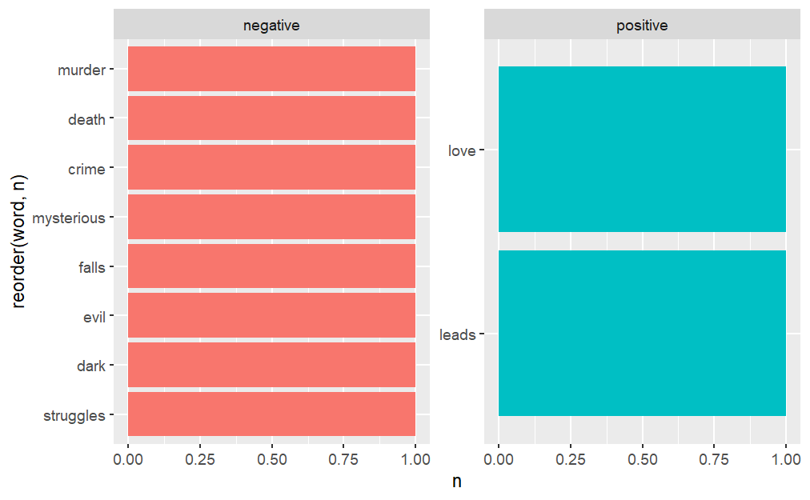

```r
Netflx_bing %>%
  filter(n>2500) %>% #  filter only those frequency greater than 2500
mutate(word = reorder(word, n)) %>%
count(word,sentiment,sort=TRUE) %>%
group_by(sentiment) %>%
  top_n(n=10) %>%
ungroup() %>%
  ggplot(aes(x=reorder(word,n),y=n,fill=sentiment)) +
  geom_col(show.legend = FALSE) +
  facet_wrap(~sentiment,scales="free") +
  coord_flip()
```

Let’s do a comparision between sentiments and lexicons for the “type” of the Netflix: TV show or Movie

```r
Netflx_bingnrc <- bind_rows(Netflx_type %>%
inner_join(get_sentiments("bing")) %>%
mutate(method = "Bing et al."),Netflx_type %>%
inner_join(get_sentiments("nrc") %>%
filter(sentiment %in% c("positive","negative"))) %>%
mutate(method = "NRC")) %>%
count(method, index = type, sentiment) %>%
spread(sentiment, n, fill = 0) %>%
mutate(sentiment = positive - negative)
Netflx_bingnrc
```

| method | index | negative | positive | sentiment |
| --- | --- | --- | --- | --- |
| Bing et al. | Movie | 8331 | 4655 | -3676 |
| Bing et al. | TV Show | 3012 | 2471 | -541 |
| NRC | Movie | 8787 | 10501 | 1714 |
| NRC | TV Show | 3137 | 4743 | 1606 |

```r
Netflx_bingnrc <- bind_rows(Netflx_type %>%
inner_join(get_sentiments("bing")) %>%
mutate(method = "Bing et al."),Netflx_type %>%
inner_join(get_sentiments("nrc") %>%
filter(sentiment %in% c("positive","negative"))) %>%
mutate(method = "NRC")) %>%
count(method, index = word, sentiment) %>% # try to change index "word" or "type"
spread(sentiment, n, fill = 0) %>%
mutate(sentiment = positive - negative)
Netflx_bingnrc
```

| method | index | negative | positive | sentiment |
| --- | --- | --- | --- | --- |
| Bing et al. | abnormal | 2 | 0 | -2 |
| Bing et al. | abolish | 1 | 0 | -1 |
| Bing et al. | abominable | 1 | 0 | -1 |
| Bing et al. | abound | 0 | 4 | 4 |
| Bing et al. | abrupt | 2 | 0 | -2 |
| Bing et al. | abruptly | 5 | 0 | -5 |
| Bing et al. | absence | 5 | 0 | -5 |
| Bing et al. | absurd | 6 | 0 | -6 |
| Bing et al. | abundance | 0 | 1 | 1 |
| Bing et al. | abuse | 22 | 0 | -22 |

[output cut: 990 more lines]

How much each word contributes to the overall sentiment of the descriptions .

```r
Netflix_bingcounts <- Netflx_bing %>%
inner_join(get_sentiments("bing")) %>%
count(word, sentiment, sort = TRUE) %>%
ungroup()
Netflix_bingcounts
```

| word | sentiment | n |
| --- | --- | --- |
| abnormal | negative | 1 |
| abolish | negative | 1 |
| abominable | negative | 1 |
| abound | positive | 1 |
| abrupt | negative | 1 |
| abruptly | negative | 1 |
| absence | negative | 1 |
| absurd | negative | 1 |
| abundance | positive | 1 |
| abuse | negative | 1 |

[output cut: 990 more lines]

[figure not shown]

```r
Netflix_bingcounts %>%
 group_by(sentiment) %>%
#top_n(2) %>%
ungroup() %>%
mutate(word = reorder(word, n)) %>%
ggplot(aes(word, n, fill = sentiment)) +
geom_col(show.legend = FALSE) +
facet_wrap(~sentiment, scales = "free_y") +
coord_flip() +
theme_fivethirtyeight() +
ggtitle("Words' Contribution to Sentiment in Netflix description", subtitle = "Using the Bing et. al Lexicon")
```

```r
Netflx_nrccounts <- Netflx_nrc %>%
inner_join(get_sentiments("nrc")) %>%
filter(sentiment %in% c("positive","negative")) %>%
count(word, sentiment, sort = TRUE) %>%
ungroup()
Netflx_nrccounts
```

| word | sentiment | n |
| --- | --- | --- |
| abandon | negative | 1 |
| abandoned | negative | 1 |
| abandonment | negative | 1 |
| abduction | negative | 1 |
| ability | positive | 1 |
| abnormal | negative | 1 |
| abolish | negative | 1 |
| abominable | negative | 1 |
| abortion | negative | 1 |
| absence | negative | 1 |

[output cut: 990 more lines]

[figure not shown]

```r
Netflx_nrccounts %>%
group_by(sentiment) %>%
top_n(20) %>%
ungroup() %>%
mutate(word = reorder(word, n)) %>%
ggplot(aes(word, n, fill = sentiment)) +
geom_col(show.legend = FALSE) +
facet_wrap(~sentiment, scales = "free_y") +
coord_flip() +
theme_fivethirtyeight() +
ggtitle("Words' Contribution to Sentiment in Netflix", subtitle = "Using the NRC Lexicon")
```

More info: https://github.com/EGjika